# Explanatory Analysis on Factors that affect Salary in the US

### by

### Chukwudi Collins Ozoede

## Investigation Overview

In this investigation, I tried to look at the factors that affect wages in the US, Investigation was carried out on:

- age
- sex
- education
- relationship
- work hour (hour-per-week)

## Distribution of Salary

> My analysis is based heavily on salary so it is only logical that I have to see the distribution of salary across the population. I can observe from my pie chart below that about 76% of the people earn 50k and below while 24% earn above 50k. So let's see how 24% of the population could cross the 50k dollar mark.

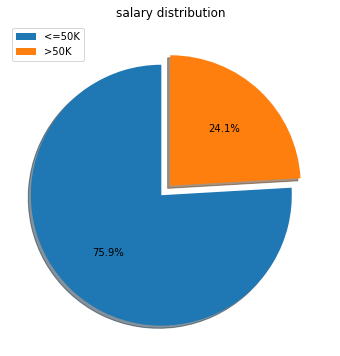

## Salary by Age and Age Group

> Looking at both charts below, I can say that people between the ages of 30 and 60 years are more likely to earn above 50k, 40 years being the most likely, people below 30 years are likely earning 50k or less. people who are above 60 years are very few on both plots

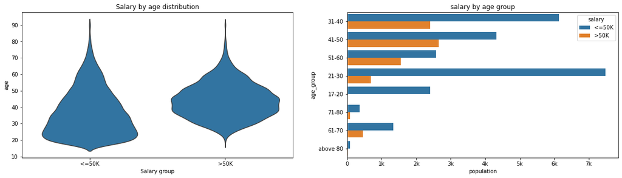

## Salary by Education

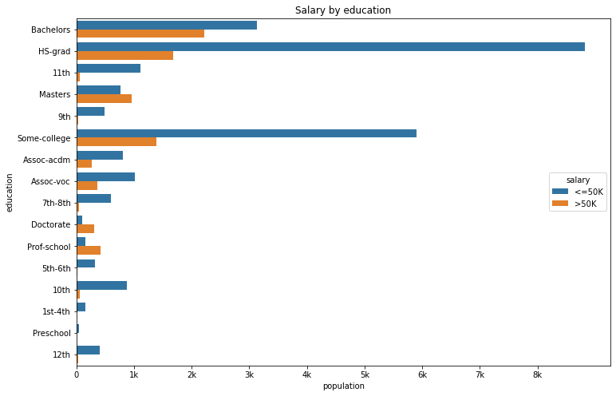

## Corelation between Salary and Relationship

> generally married people earn higher than unmarried people. `Husband` has the highest population in the chart and also with a good number of people earning above 50k,`wife` has the highest ratio of people earning above 50k too though the population of `wife` is low. `Not-in-family` has a huge population but most of them earn below 50k

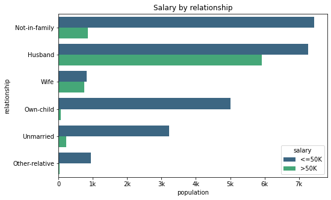

## Salary by Age and Sex relationship

Irrespective of the gender, more people earn 50k and below. The least prepresented set in the chart are women who earn above 50k. Young adults below the age of 30 and people above 60 are less likely to ean above 50k, infact only one person per gender below the age of 20 earns above 50k.people who earn above 50k are mostly men between 30 and 60 years.

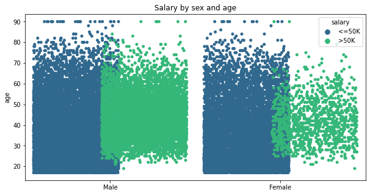

## Salary by Education and workhour/week

I cannot see any pattern or correlation between education level and how long people worked, the only take away is that people that earn above 50k generally work for longer hours than their counterparts with the same education level. I also found out that nobody with a `preschool` qualification earns more than 50k.

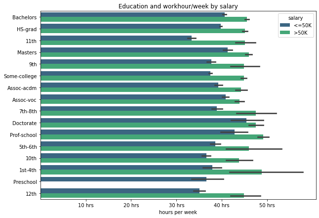